# Estudis d'Informàtica, Multimedia i Telecomunicacions

# Mineria de dades: PAC3 - Classificació amb arbres de decisió

Autor: Salvador Sanchis Beneseit

Maig 2022

# Classificació amb arbres de decisió

## Anàlisi descriptiu i de correlacions

Carreguem les dades:

```r
credit <- read.csv("~/Desktop/DS/22:1/Data Mining/PAC/3/credit.csv", stringsAsFactors=TRUE)
```

Mostrem les dimensions del dataset. Veiem que hi ha 1000 registres de 21 variables, i que no hi ha cap valor buit. Visualitzem també un resum inicial de totes les variables:

```r
dim(credit)
```

```
## [1] 1000   21
```

```r
missing <- credit[is.na(credit),]
dim(missing)
```

```
## [1]  0 21
```

```r
summary(credit)
```

```
##    checking_balance months_loan_duration                credit_history
##  < 0 DM    :274     Min.   : 4.0         critical              :293
##  > 200 DM  : 63     1st Qu.:12.0         delayed               : 88
##  1 - 200 DM:269     Median :18.0         fully repaid          : 40
##  unknown   :394     Mean   :20.9         fully repaid this bank: 49
##                     3rd Qu.:24.0         repaid                :530
##                     Max.   :72.0
##
##        purpose        amount           savings_balance  employment_length
##  radio/tv  :280   Min.   :  250   < 100 DM     :603    > 7 yrs   :253
##  car (new) :234   1st Qu.: 1366   > 1000 DM    : 48    0 - 1 yrs :172
##  furniture :181   Median : 2320   101 - 500 DM :103    1 - 4 yrs :339
##  car (used):103   Mean   : 3271   501 - 1000 DM: 63    4 - 7 yrs :174
##  business  : 97   3rd Qu.: 3972   unknown      :183    unemployed: 62
##  education : 50   Max.   :18424
##  (Other)   : 55
##  installment_rate      personal_status      other_debtors residence_history
##  Min.   :1.000    divorced male: 50    co-applicant: 41   Min.   :1.000
##  1st Qu.:2.000    female       :310    guarantor   : 52   1st Qu.:2.000
##  Median :3.000    married male : 92    none        :907   Median :3.000
##  Mean   :2.973    single male  :548                       Mean   :2.845
##  3rd Qu.:4.000                                            3rd Qu.:4.000
##  Max.   :4.000                                            Max.   :4.000
##
##                      property        age        installment_plan     housing
##  building society savings:232   Min.   :19.00   bank  :139       for free:108
##  other                   :332   1st Qu.:27.00   none  :814       own     :713
##  real estate             :282   Median :33.00   stores: 47       rent    :179
##  unknown/none            :154   Mean   :35.55
##                                 3rd Qu.:42.00
##                                 Max.   :75.00
##
##  existing_credits    default      dependents    telephone  foreign_worker
##  Min.   :1.000    Min.   :1.0   Min.   :1.000   none:596   no : 37
##  1st Qu.:1.000    1st Qu.:1.0   1st Qu.:1.000   yes :404   yes:963
##  Median :1.000    Median :1.0   Median :1.000
##  Mean   :1.407    Mean   :1.3   Mean   :1.155
##  3rd Qu.:2.000    3rd Qu.:2.0   3rd Qu.:1.000
##  Max.   :4.000    Max.   :2.0   Max.   :2.000
##
##                       job
##  mangement self-employed:148
##  skilled employee       :630
##  unemployed non-resident: 22
##  unskilled resident     :200
##
##
##
```

A primera vista, ens adonem que hi ha una gran quantitat de variables categòriques. Algunes d’elles tenen a veure amb característiques qualitatives, com l’estat civil, o el tipus de feina. Tanmateix, també hi ha moltes variables categoritzades que provenen de mesures numèriques constants, com les variables ‘checking balance’, ‘savings balance’ o ‘employment length’. Proposem estendre aquesta lògica a totes les variables numèriques, i per tant farem un estudi de diverses variables i crearem categories per la variables numèriques contínues. Considerem que un dataset on totes les variables siguin categòriques serà més coherent i més fàcil d’interpretar un cop hi apliquem algorismes d’arbres de decisió.

En primer lloc, per clarificar-ne el significat, canviarem el nom de la variable ‘installment plan’:

```r
names(credit)[names(credit) == "installment_plan"] <- "other_installment_plan"
```

Per decidir quin tipus de discretització realitzem, analitzem la distribució de la variable ‘amount’:

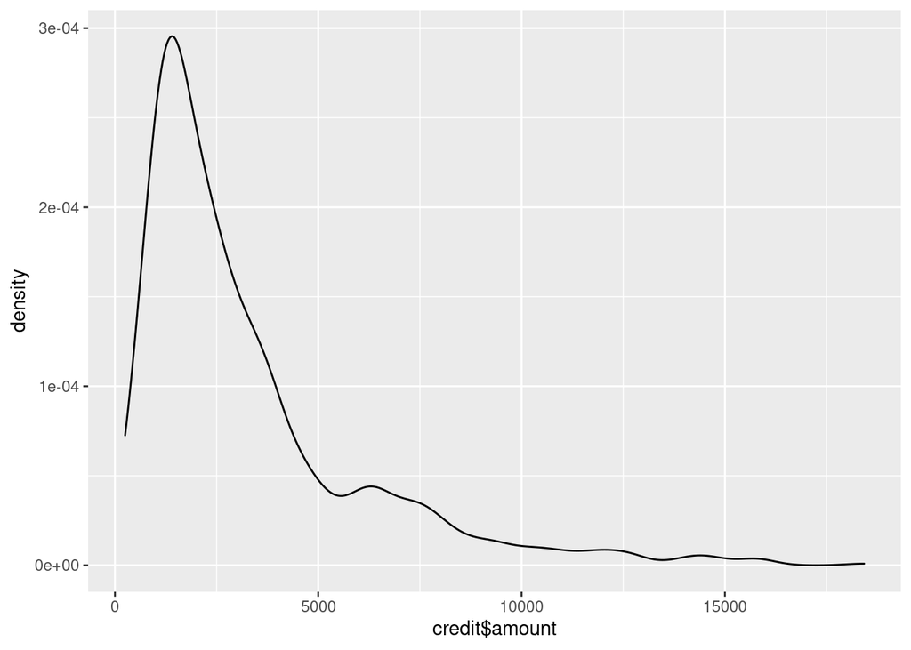

```r
library(ggplot2)
ggplot(mapping = aes(credit$amount)) + geom_density()
```

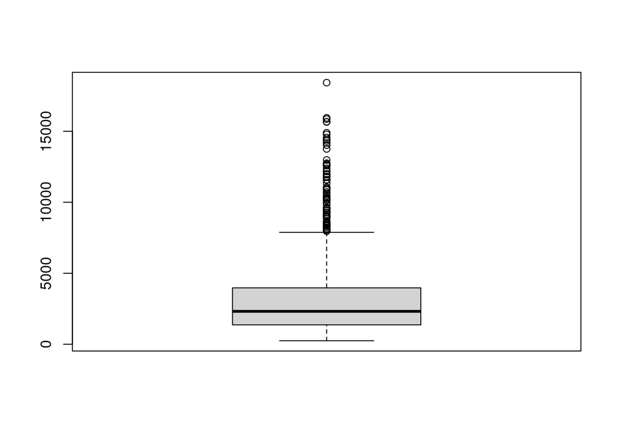

```r
boxplot(credit$amount)
```

Observem una forta asimetria i una sèrie de valors extrems, però entenem que no es tracta de registres erronis.

Observem en detall els registres amb els valors més alts de ‘amount’:

```r
sort_by_amount <- credit[order(credit$amount,decreasing = TRUE), ]
head(sort_by_amount)
```

```
##     checking_balance months_loan_duration credit_history   purpose amount
## 916       1 - 200 DM                   48   fully repaid    others  18424
## 96        1 - 200 DM                   54   fully repaid  business  15945
## 819           < 0 DM                   36         repaid    others  15857
## 888       1 - 200 DM                   48         repaid  business  15672
## 638          unknown                   60        delayed  radio/tv  15653
## 918           < 0 DM                    6         repaid car (new)  14896
##     savings_balance employment_length installment_rate personal_status
## 916        < 100 DM         1 - 4 yrs                1          female
## 96         < 100 DM         0 - 1 yrs                3     single male
## 819        < 100 DM        unemployed                2   divorced male
## 888        < 100 DM         1 - 4 yrs                2     single male
## 638        < 100 DM         4 - 7 yrs                2     single male
## 918        < 100 DM           > 7 yrs                1     single male
##     other_debtors residence_history                 property age
```

[output cut: 20 more lines]

Decidim utilitzar el mètode k-means per crear una variable discreta amb tres nivells:

```r
library(arules)
credit$amount_d <- discretize(credit$amount, method = "cluster", labels = c("low", "medium", "high"))
```

```r
summary(credit$amount_d)
```

```
##    low medium   high
##    728    216     56
```

```r
amount_low <- credit[credit$amount_d == 'low',]
amount_medium <- credit[credit$amount_d == 'medium',]
amount_high <- credit[credit$amount_d == 'high',]

summary(amount_low$amount)
```

```
##    Min. 1st Qu.  Median    Mean 3rd Qu.    Max.
##     250    1235    1745    1890    2569    3812
```

```r
summary(amount_medium$amount)
```

```
##    Min. 1st Qu.  Median    Mean 3rd Qu.    Max.
##    3832    4461    5726    5742    6856    8648
```

```r
summary(amount_high$amount)
```

```
##    Min. 1st Qu.  Median    Mean 3rd Qu.    Max.
##    8858    9800   11191   11696   12806   18424
```

En aquest últim resum veiem quines són les quantitats dels crèdits que caracteritzen cadascun dels grups resultants del procés de discretització: de 250DM a 3812DM, de 3832DM a 8648DM, i de 8858DM a 18424DM.

Tot seguit, visualitzem la distribució de la variable que mesura la llargada del crèdit en mesos:

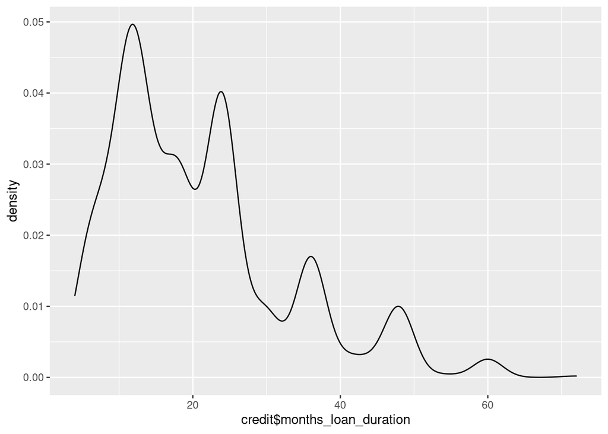

```r
ggplot(mapping = aes(credit$months_loan_duration)) + geom_density()
```

En aquest cas, decidim crear de forma manual quatre grups, agrupant mesos en anys:

```r
credit$credit_duration_d <- discretize(credit$months_loan_duration, method = "fixed", breaks = c(-Inf, 12, 24, 37, Inf),labels = c("<1 year", "1 to 2 years", "2 to 3 years", ">3 years"))
summary(credit$credit_duration_d)
```

```
##      <1 year 1 to 2 years 2 to 3 years     >3 years
##          180          406          327           87
```

Visualitzem la distribució de la variable edat:

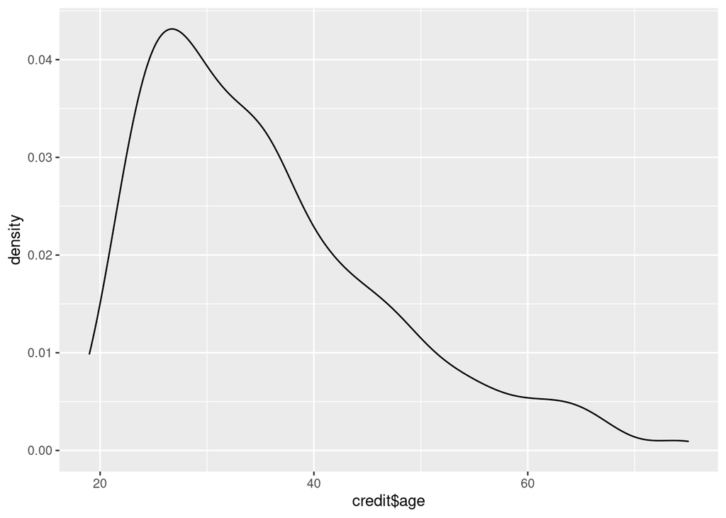

```r
ggplot(mapping = aes(credit$age)) + geom_density()
```

En aquest cas també ens decantem per una discretització manual guiant-nos per mesures de caire més aviat psico-social, amb menors de 30 anys i majors de 60 en els extrems, i separant dècades entremig:

```r
credit$age_d <- discretize(credit$age, method = "fixed", breaks = c(-Inf, 30, 41, 51, 61, Inf),labels = c("<30", "30 to 40", "41 to 50", "51 to 60", ">60"))
summary(credit$age_d)
```

```
##      <30 30 to 40 41 to 50 51 to 60      >60
##      371      355      161       68       45
```

Mostrem un resum d’altres variables que en principi són contínues, però que sospitem que contenen un nombre limitat de valors:

```r
summary(as.factor(credit$installment_rate))
```

```
##   1   2   3   4
## 136 231 157 476
```

```r
summary(as.factor(credit$residence_history))
```

```
##   1   2   3   4
## 130 308 149 413
```

```r
summary(as.factor(credit$existing_credits))
```

```
##   1   2   3   4
## 633 333  28   6
```

```r
summary(as.factor(credit$dependents))
```

```
##   1   2
## 845 155
```

Un cop confirmades les nostre sospites, categoritzem totes aquestes variables. En aquesta operació també inclourem la categorització de la variable ‘default’, que serà la nostra variable classificadora, i hi afegim etiquetes per clarificar-ne el significat:

```r
credit$installment_rate <- as.factor(credit$installment_rate)
credit$residence_history <- as.factor(credit$residence_history)
credit$existing_credits <- as.factor(credit$existing_credits)
credit$dependents <- as.factor(credit$dependents)

credit$default <- as.factor(credit$default)
levels(credit$default) <- c('no default', 'default')
```

Mostrem un nou resum havent fer aquestes modificacions inicials, i ja amb possessió de variables categòriques que inclouen tota la informació del joc de dades:

```r
summary(credit)
```

```
##    checking_balance months_loan_duration                credit_history
##  < 0 DM    :274     Min.   : 4.0         critical              :293
##  > 200 DM  : 63     1st Qu.:12.0         delayed               : 88
##  1 - 200 DM:269     Median :18.0         fully repaid          : 40
##  unknown   :394     Mean   :20.9         fully repaid this bank: 49
##                     3rd Qu.:24.0         repaid                :530
##                     Max.   :72.0
##
##        purpose        amount           savings_balance  employment_length
##  radio/tv  :280   Min.   :  250   < 100 DM     :603    > 7 yrs   :253
##  car (new) :234   1st Qu.: 1366   > 1000 DM    : 48    0 - 1 yrs :172
##  furniture :181   Median : 2320   101 - 500 DM :103    1 - 4 yrs :339
##  car (used):103   Mean   : 3271   501 - 1000 DM: 63    4 - 7 yrs :174
##  business  : 97   3rd Qu.: 3972   unknown      :183    unemployed: 62
##  education : 50   Max.   :18424
##  (Other)   : 55
##  installment_rate      personal_status      other_debtors residence_history
##  1:136            divorced male: 50    co-applicant: 41   1:130
##  2:231            female       :310    guarantor   : 52   2:308
##  3:157            married male : 92    none        :907   3:149
##  4:476            single male  :548                       4:413
##
##
##
##                      property        age        other_installment_plan
##  building society savings:232   Min.   :19.00   bank  :139
##  other                   :332   1st Qu.:27.00   none  :814
##  real estate             :282   Median :33.00   stores: 47
##  unknown/none            :154   Mean   :35.55
##                                 3rd Qu.:42.00
##                                 Max.   :75.00
##
##      housing    existing_credits       default    dependents telephone
##  for free:108   1:633            no default:700   1:845      none:596
##  own     :713   2:333            default   :300   2:155      yes :404
##  rent    :179   3: 28
##                 4:  6
##
##
##
##  foreign_worker                      job        amount_d      credit_duration_d
##  no : 37        mangement self-employed:148   low   :728   <1 year     :180
##  yes:963        skilled employee       :630   medium:216   1 to 2 years:406
##                 unemployed non-resident: 22   high  : 56   2 to 3 years:327
##                 unskilled resident     :200                >3 years    : 87
##
##
##
##       age_d
##  <30     :371
##  30 to 40:355
##  41 to 50:161
##  51 to 60: 68
##  >60     : 45
##
##
```

## Visualitzacions, taules i tests estadístics

A partir d’aquest punt, proposem estudiar totes les variables analitzant-ne la possible relació amb la variable ‘default’. Per a cada variable visualitzarem els nivells de la variable en relació amb la variable ‘default’, mostrarem els percentatges d’aquesta relació en una taula, i també mostrarem valors del test de V de Cramer per tal de mostrar la significància estadística de l’associació entre els nivells de la variable i la variable ‘default’.

```r
if(!require(ggplot2)){
    install.packages('ggplot2', repos='http://cran.us.r-project.org')
    library(ggplot2)
}
```

```r
if(!require(grid)){
    install.packages('grid', repos='http://cran.us.r-project.org')
    library(grid)
}
if(!require(gridExtra)){
    install.packages('gridExtra', repos='http://cran.us.r-project.org')
    library(gridExtra)
}
if(!require(C50)){
    install.packages('C50', repos='http://cran.us.r-project.org')
    library(C50)
}
if(!require(DescTools)){
    install.packages('DescTools', repos='http://cran.us.r-project.org')
    library(DescTools)
}
```

### Checking Balance i Credit Duration:

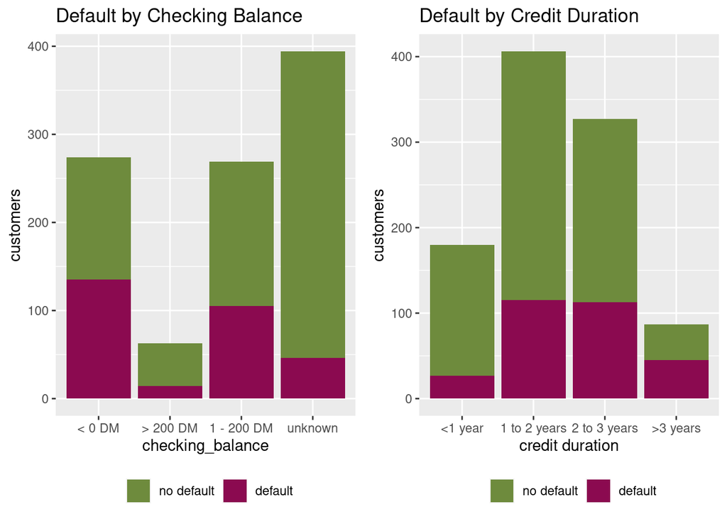

```r
grid.newpage()

plotbyCheckBalance<-ggplot(credit,aes(checking_balance,fill=default))+geom_bar() +labs(x="checking_balance", y="customers")+ guides(fill=guide_legend(title=""))+ theme(legend.position = 'bottom')+ scale_fill_manual(values=c("darkolivegreen4","deeppink4"))+ggtitle("Default by Checking Balance")
plotbyCreditDuration<-ggplot(credit,aes(credit_duration_d,fill=default))+geom_bar() +labs(x="credit duration", y="customers")+ guides(fill=guide_legend(title=""))+  theme(legend.position = 'bottom')+ scale_fill_manual(values=c("darkolivegreen4","deeppink4"))+ggtitle("Default by Credit Duration")

grid.arrange(plotbyCheckBalance, plotbyCreditDuration, ncol=2)
```

```r
t_check_balance <- prop.table(table(credit$checking_balance, credit$default), margin=1)
t_credit_duration <- prop.table(table(credit$credit_duration_d, credit$default), margin=1)
round(t_check_balance, 2)
```

```
##
##              no default default
##   < 0 DM           0.51    0.49
##   > 200 DM         0.78    0.22
##   1 - 200 DM       0.61    0.39
##   unknown          0.88    0.12
```

```r
round(t_credit_duration, 2)
```

```
##
##                no default default
##   <1 year            0.85    0.15
##   1 to 2 years       0.72    0.28
##   2 to 3 years       0.65    0.35
##   >3 years           0.48    0.52
```

```r
CramerV(t_check_balance)
```

```
## [1] 0.3161049
```

```r
CramerV(t_credit_duration)
```

```
## [1] 0.2821446
```

L’anàlisi ens mostra que en la variable ‘checking balance’ hi ha un patró, segons el qual com més diners hi ha al compte corrent del client, menys possibilitat hi ha que hi hagi impagament. Pel que fa a la duració del crèdit, també hi podem trobar una relació: com més llarg és el crèdit més alt és el percentatge de clients amb impagament (fins superar el 50% en el cas de crèdits de més de 3 anys). En ambdós casos l’associació estadística no és gaire alta.

### Credit History:

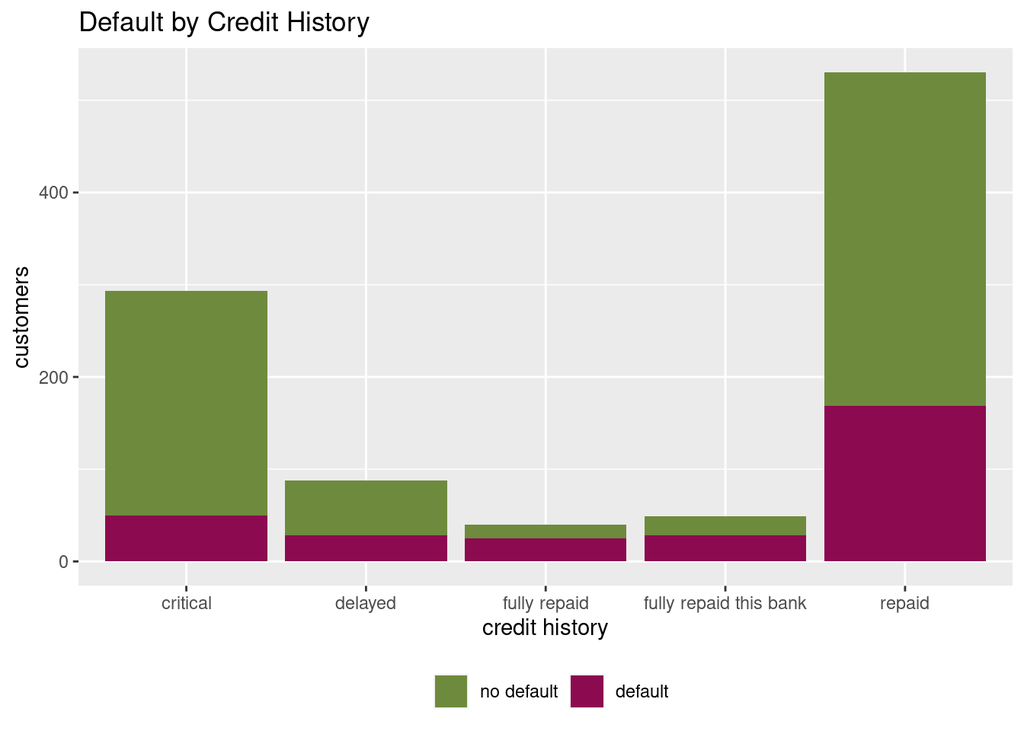

```r
plotbyCreditHistory<-ggplot(credit,aes(credit_history,fill=default))+geom_bar() +labs(x="credit history", y="customers")+ guides(fill=guide_legend(title=""))+  theme(legend.position = 'bottom')+ scale_fill_manual(values=c("darkolivegreen4","deeppink4"))+ggtitle("Default by Credit History")

plotbyCreditHistory
```

```r
t_credit_history <- prop.table(table(credit$credit_history, credit$default), margin=1)
round(t_credit_history, 2)
```

```
##
##                          no default default
##   critical                     0.83    0.17
##   delayed                      0.68    0.32
##   fully repaid                 0.38    0.62
##   fully repaid this bank       0.43    0.57
##   repaid                       0.68    0.32
```

```r
CramerV(t_credit_history)
```

```
## [1] 0.3485545
```

La variable ‘Credit History’ és qualitativa, i mostra una gran diferència entre el grup ‘critical’ amb un percentatge molt petit d’impagaments, i el grup ‘fully repaid’, amb un 62% d’impagaments. L’associació estadística emb la variable default és mitjana.

### Credit Amount i Housing:

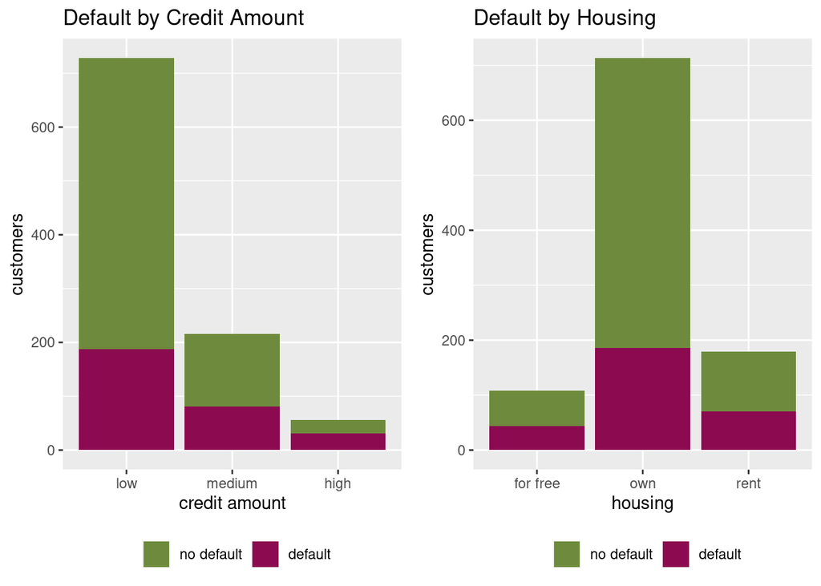

```r
plotbyCreditAmount<-ggplot(credit,aes(amount_d,fill=default))+geom_bar() +labs(x="credit amount", y="customers")+ guides(fill=guide_legend(title=""))+  theme(legend.position = 'bottom')+ scale_fill_manual(values=c("darkolivegreen4","deeppink4"))+ggtitle("Default by Credit Amount")
plotbyHousing<-ggplot(credit,aes(housing,fill=default))+geom_bar() +labs(x="housing", y="customers")+ guides(fill=guide_legend(title=""))+  theme(legend.position = 'bottom')+ scale_fill_manual(values=c("darkolivegreen4","deeppink4"))+ggtitle("Default by Housing")

grid.arrange(plotbyCreditAmount, plotbyHousing, ncol=2)
```

```r
t_credit_amount <- prop.table(table(credit$amount_d, credit$default), margin=1)
t_housing <- prop.table(table(credit$housing, credit$default), margin=1)
round(t_credit_amount, 2)
```

```
##
##          no default default
##   low          0.74    0.26
##   medium       0.62    0.38
##   high         0.45    0.55
```

```r
round(t_housing, 2)
```

```
##
##            no default default
##   for free       0.59    0.41
##   own            0.74    0.26
##   rent           0.61    0.39
```

```r
CramerV(t_credit_amount)
```

```
## [1] 0.2483638
```

```r
CramerV(t_housing)
```

```
## [1] 0.137186
```

La quantitat de diners del crèdit també sembla relacionar-se clarament amb els impagaments: com més diners en crèdit, més impagament. Pel que fa al tipus d’allotjament, els nivells d’impagament són comparativament més baixos en clients que viuen en habitatges de propietat. L’associació estadística és més aviat baixa en ambdues variables.

### Installment Rate, Other Installment Plan i Other Existing Credits:

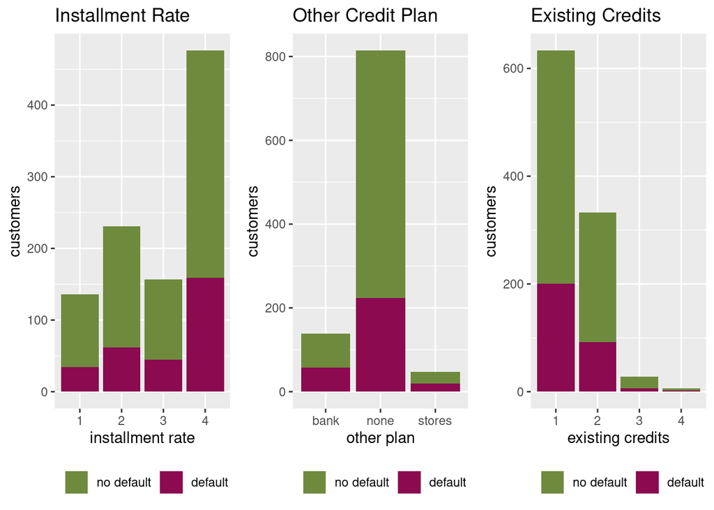

```r
plotbyInstallmentRate<-ggplot(credit,aes(installment_rate,fill=default))+geom_bar() +labs(x="installment rate", y="customers")+ guides(fill=guide_legend(title=""))+  theme(legend.position = 'bottom')+ scale_fill_manual(values=c("darkolivegreen4","deeppink4"))+ggtitle("Installment Rate")
plotbyOtherPlan<-ggplot(credit,aes(other_installment_plan,fill=default))+geom_bar() +labs(x="other plan", y="customers")+ guides(fill=guide_legend(title=""))+  theme(legend.position = 'bottom')+ scale_fill_manual(values=c("darkolivegreen4","deeppink4"))+ggtitle("Other Credit Plan")
plotbyExistingCredits<-ggplot(credit,aes(existing_credits,fill=default))+geom_bar() +labs(x="existing credits", y="customers")+ guides(fill=guide_legend(title=""))+  theme(legend.position = 'bottom')+ scale_fill_manual(values=c("darkolivegreen4","deeppink4"))+ggtitle("Existing Credits")

grid.arrange(plotbyInstallmentRate, plotbyOtherPlan, plotbyExistingCredits, ncol=3)
```

```r
t_installment <- prop.table(table(credit$installment_rate, credit$default), margin=1)
t_other_plan <- prop.table(table(credit$other_installment_plan, credit$default), margin=1)
t_existing_credits <- prop.table(table(credit$existing_credits, credit$default), margin=1)

round(t_installment, 2)
```

```
##
##     no default default
##   1       0.75    0.25
##   2       0.73    0.27
##   3       0.71    0.29
##   4       0.67    0.33
```

```r
round(t_other_plan, 2)
```

```
##
##          no default default
##   bank         0.59    0.41
##   none         0.72    0.28
##   stores       0.60    0.40
```

```r
round(t_existing_credits, 2)
```

```
##
##     no default default
##   1       0.68    0.32
##   2       0.72    0.28
##   3       0.79    0.21
##   4       0.67    0.33
```

```r
CramerV(t_installment)
```

```
## [1] 0.06925366
```

```r
CramerV(t_other_plan)
```

```
## [1] 0.129464
```

```r
CramerV(t_existing_credits)
```

```
## [1] 0.1013444
```

Aquestes tres variables no mostren una associació gaire clara entre els seus nivells i la variable ‘default’, i l’associació estadística també és baixa. Només podem destacar que el grup de clients que no tenen cap altre pagament a terminis mostren un percentatge més baix d’impagaments.

### Dependents, Telephone i Foreign Worker:

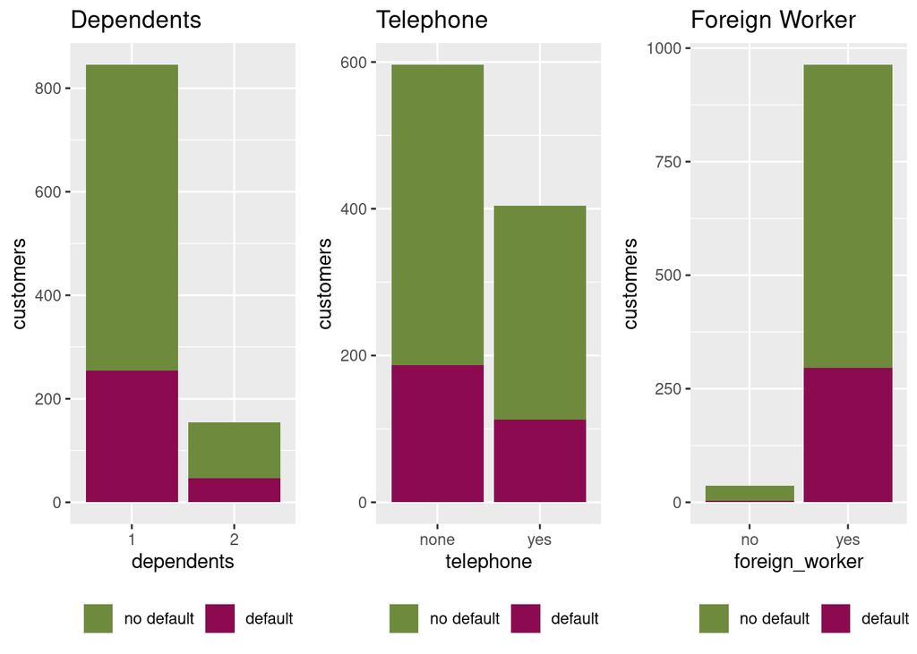

```r
plotbyDependents<-ggplot(credit,aes(dependents,fill=default))+geom_bar() +labs(x="dependents", y="customers")+ guides(fill=guide_legend(title=""))+  theme(legend.position = 'bottom')+ scale_fill_manual(values=c("darkolivegreen4","deeppink4"))+ggtitle("Dependents")
plotbyTelephone<-ggplot(credit,aes(telephone,fill=default))+geom_bar() +labs(x="telephone", y="customers")+ guides(fill=guide_legend(title=""))+  theme(legend.position = 'bottom')+ scale_fill_manual(values=c("darkolivegreen4","deeppink4"))+ggtitle("Telephone")
plotbyForeignWorker<-ggplot(credit,aes(foreign_worker,fill=default))+geom_bar() +labs(x="foreign_worker", y="customers")+ guides(fill=guide_legend(title=""))+  theme(legend.position = 'bottom')+ scale_fill_manual(values=c("darkolivegreen4","deeppink4"))+ggtitle("Foreign Worker")

grid.arrange(plotbyDependents, plotbyTelephone, plotbyForeignWorker, ncol=3)
```

```r
t_dependents <- prop.table(table(credit$dependents, credit$default), margin=1)
t_telephone <- prop.table(table(credit$telephone, credit$default), margin=1)
t_foreign <- prop.table(table(credit$foreign_worker, credit$default), margin=1)

round(t_dependents, 2)
```

```
##
##     no default default
##   1        0.7     0.3
##   2        0.7     0.3
```

```r
round(t_telephone, 2)
```

```
##
##        no default default
##   none       0.69    0.31
##   yes        0.72    0.28
```

```r
round(t_foreign, 2)
```

```
##
##       no default default
##   no        0.89    0.11
##   yes       0.69    0.31
```

```r
CramerV(t_dependents)
```

```
## [1] 0.00417051
```

```r
CramerV(t_telephone)
```

```
## [1] 0.0372747
```

```r
CramerV(t_foreign)
```

```
## [1] 0.2455874
```

En aquestes tres variables no hi detectem un patró d’associació clar, però cal esmentar un parell d’aspectes que ens semblen rellevants. En la variable ‘dependents’, que en principi mesura el nombre de persones dependents del client del crèdit, i que en el dataset se’ns presenta com a variable numèrica, ens sobta que els dos únics valors pissibles siguin ‘1’ i ‘2’. Semblaria voler dir que no hi ha cap persona a la mostra que no tingui cap altra persona dependent, ni tampoc que en tingui 3 o més.

D’altra banda, la variable ‘foreign worker’ sí que sembla tenir una relació amb la variable ‘default’, però en aquest cas ens sobta que la quantitat de treballadors estrangers sigui tan alta. Sospitem que, en aquest sentit, no estem davant d’una mostra aleatòria:

```r
summary(credit$foreign_worker)
```

```
##  no yes
##  37 963
```

### Employment Length:

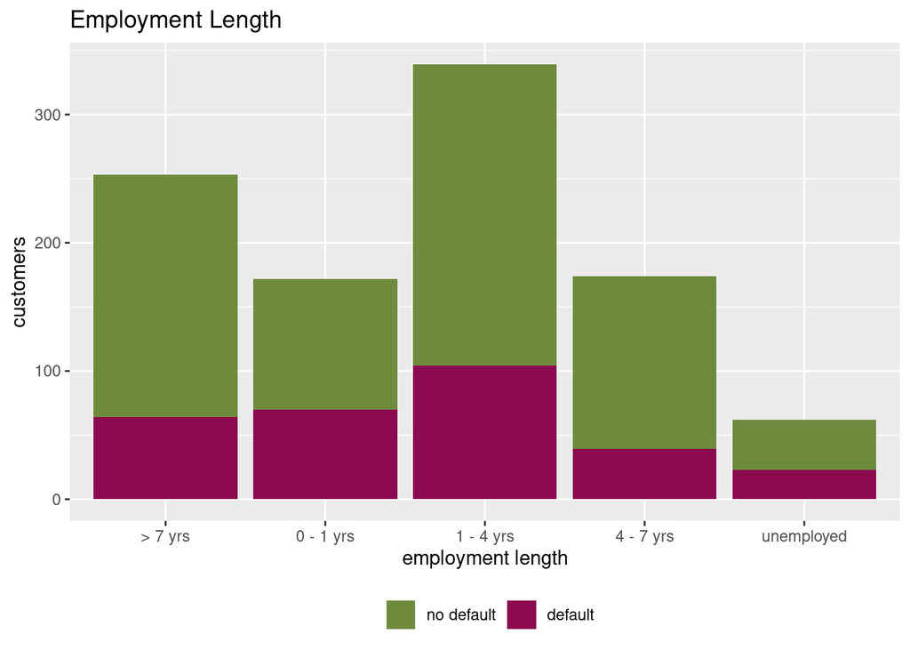

```r
plotbyEmploymentLength<-ggplot(credit,aes(employment_length,fill=default))+geom_bar() +labs(x="employment length", y="customers")+ guides(fill=guide_legend(title=""))+  theme(legend.position = 'bottom')+ scale_fill_manual(values=c("darkolivegreen4","deeppink4"))+ggtitle("Employment Length")

plotbyEmploymentLength
```

```r
t_employment_length <- prop.table(table(credit$employment_length, credit$default), margin=1)
round(t_employment_length, 2)
```

```
##
##              no default default
##   > 7 yrs          0.75    0.25
##   0 - 1 yrs        0.59    0.41
##   1 - 4 yrs        0.69    0.31
##   4 - 7 yrs        0.78    0.22
##   unemployed       0.63    0.37
```

```r
CramerV(t_employment_length)
```

```
## [1] 0.1486436
```

En la variable que mesura la llargada del contracte laboral, veiem que com més curt el contracte major és el percentatge d’impagaments. L’associació estadística és feble.

### Savings Balance:

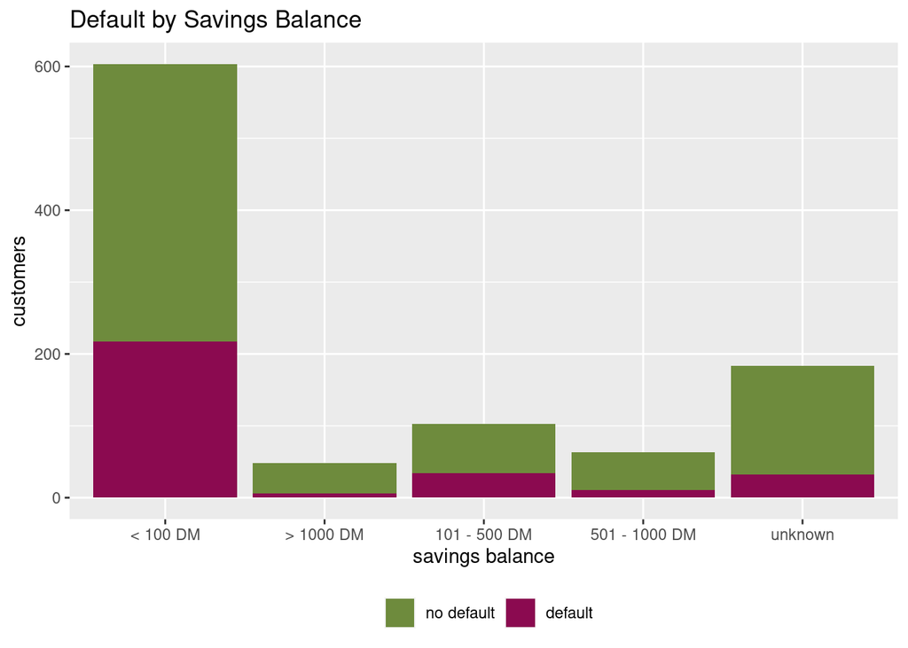

```r
plotbySavings<-ggplot(credit,aes(savings_balance,fill=default))+geom_bar() +labs(x="savings balance", y="customers")+ guides(fill=guide_legend(title=""))+  theme(legend.position = 'bottom')+ scale_fill_manual(values=c("darkolivegreen4","deeppink4"))+ggtitle("Default by Savings Balance")

plotbySavings
```

```r
t_savings <- prop.table(table(credit$savings_balance, credit$default), margin=1)
round(t_savings, 2)
```

```
##
##                 no default default
##   < 100 DM            0.64    0.36
##   > 1000 DM           0.88    0.12
##   101 - 500 DM        0.67    0.33
##   501 - 1000 DM       0.83    0.17
##   unknown             0.83    0.17
```

```r
CramerV(t_savings)
```

```
## [1] 0.2218844
```

Pel que fa a la quantitat d’estalvis, l’anàlisi ens confirma que els clients amb menys estalvis tendeixen en més quantitat a caure en impagament. L’associació estadística és feble.

### Purpose:

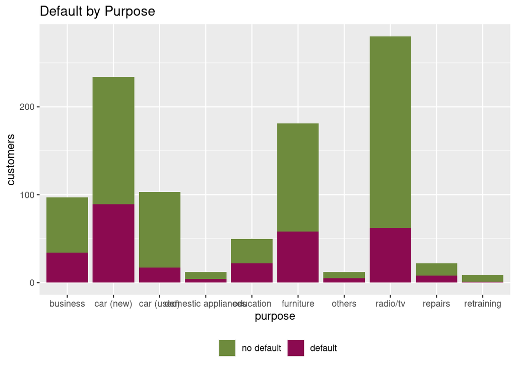

```r
plotbyPurpose <- ggplot(credit,aes(purpose, fill=default))+geom_bar() +labs(x="purpose", y="customers")+ guides(fill=guide_legend(title=""))+  theme(legend.position = 'bottom')+ scale_fill_manual(values=c("darkolivegreen4","deeppink4"))+ggtitle("Default by Purpose")

plotbyPurpose
```

```r
t_purpose <- prop.table(table(credit$purpose, credit$default), margin=1)

round(t_purpose, 2)
```

```
##
##                       no default default
##   business                  0.65    0.35
##   car (new)                 0.62    0.38
##   car (used)                0.83    0.17
##   domestic appliances       0.67    0.33
##   education                 0.56    0.44
##   furniture                 0.68    0.32
##   others                    0.58    0.42
##   radio/tv                  0.78    0.22
##   repairs                   0.64    0.36
##   retraining                0.89    0.11
```

```r
CramerV(t_purpose)
```

```
## [1] 0.2234099
```

Pel que fa al motiu del crèdit, no hi ha grans diferències. Potser només podem destacar nivells baixos d’impagaments en crèdits relacionats amb la compra de cotxes de segona mà, educació continuada i aparells de ràdio/TV. L’associació estadística és feble.

### Age i Other Debtors:

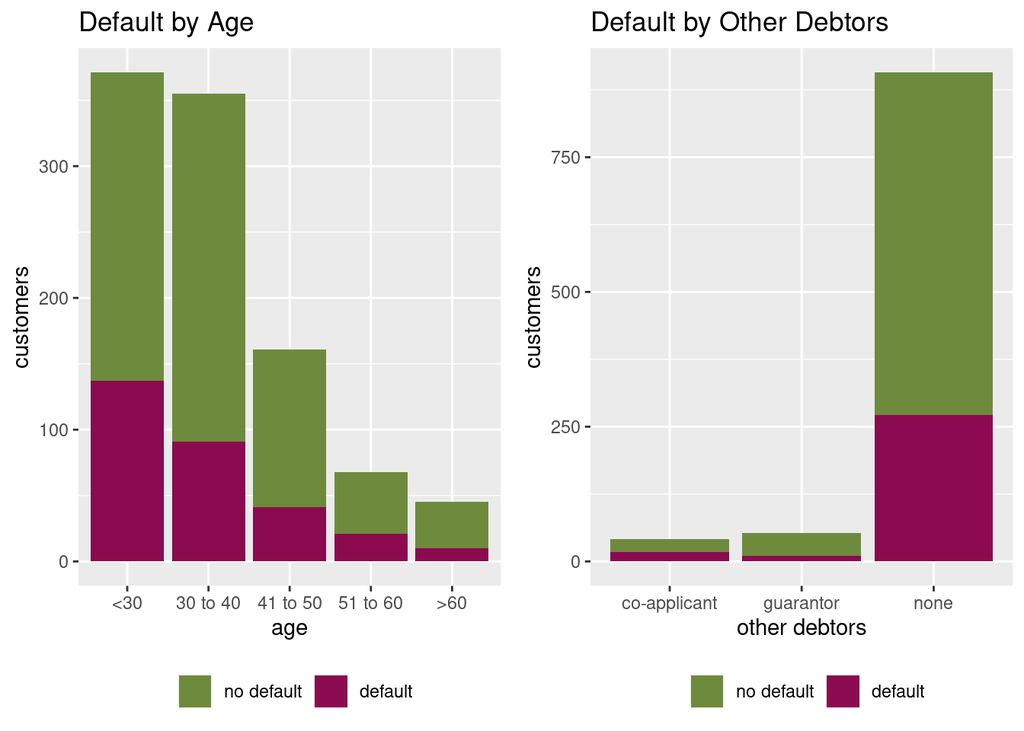

```r
plotbyAge<-ggplot(credit,aes(age_d,fill=default))+geom_bar() +labs(x="age", y="customers")+ guides(fill=guide_legend(title=""))+  theme(legend.position = 'bottom')+ scale_fill_manual(values=c("darkolivegreen4","deeppink4"))+ggtitle("Default by Age")
plotbyOtherDebtors<-ggplot(credit,aes(other_debtors,fill=default))+geom_bar() +labs(x="other debtors", y="customers")+ guides(fill=guide_legend(title=""))+  theme(legend.position = 'bottom')+ scale_fill_manual(values=c("darkolivegreen4","deeppink4"))+ggtitle("Default by Other Debtors")

grid.arrange(plotbyAge, plotbyOtherDebtors, ncol=2)
```

```r
t_age <- prop.table(table(credit$age_d, credit$default), margin=1)
t_debtors <- prop.table(table(credit$other_debtors, credit$default), margin=1)

round(t_age, 2)
```

```
##
##            no default default
##   <30            0.63    0.37
##   30 to 40       0.74    0.26
##   41 to 50       0.75    0.25
##   51 to 60       0.69    0.31
##   >60            0.78    0.22
```

```r
round(t_debtors, 2)
```

```
##
##                no default default
##   co-applicant       0.56    0.44
##   guarantor          0.81    0.19
##   none               0.70    0.30
```

```r
CramerV(t_age)
```

```
## [1] 0.1146509
```

```r
CramerV(t_debtors)
```

```
## [1] 0.2182937
```

Trobem diferències clares en l’edat només en els extrems: hi ha més impagaments entre els menors de 30 anys que en els majors de 60. Pel que fa al tipus de deutor, destaquem que els avaladors tenen un percentatge molt baix d’impagaments. L’associació estadística és feble per a les dues variables.

### Personal Status i Residence History:

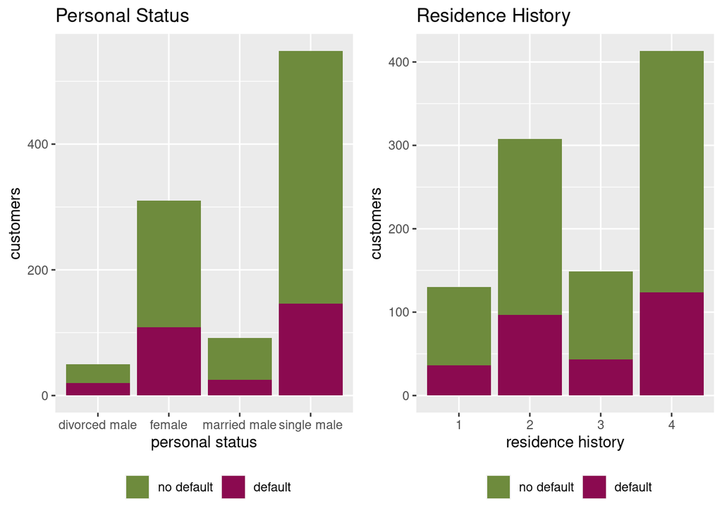

```r
plotbyPersonalStatus<-ggplot(credit,aes(personal_status,fill=default))+geom_bar() +labs(x="personal status", y="customers")+ guides(fill=guide_legend(title=""))+  theme(legend.position = 'bottom')+ scale_fill_manual(values=c("darkolivegreen4","deeppink4"))+ggtitle("Personal Status")
plotbyResidenceH<-ggplot(credit,aes(residence_history,fill=default))+geom_bar() +labs(x="residence history", y="customers")+ guides(fill=guide_legend(title=""))+  theme(legend.position = 'bottom')+ scale_fill_manual(values=c("darkolivegreen4","deeppink4"))+ggtitle("Residence History")


grid.arrange(plotbyPersonalStatus, plotbyResidenceH, ncol=2)
```

```r
t_status <- prop.table(table(credit$personal_status, credit$default), margin=1)
t_p_history <- prop.table(table(credit$residence_history, credit$default), margin=1)

round(t_status, 2)
```

```
##
##                 no default default
##   divorced male       0.60    0.40
##   female              0.65    0.35
##   married male        0.73    0.27
##   single male         0.73    0.27
```

```r
round(t_p_history, 2)
```

```
##
##     no default default
##   1       0.72    0.28
##   2       0.69    0.31
##   3       0.71    0.29
##   4       0.70    0.30
```

```r
CramerV(t_status)
```

```
## [1] 0.1199569
```

```r
CramerV(t_p_history)
```

```
## [1] 0.03086199
```

La variable d’històric de residència no mostra diferències remarcables entre els seus nivells. Ens sobta d’aquesta variable, inicialment numèrica, que tots els possibles valors estiguin entre 1 i 4.

Pel que fa a la variable ‘personal status’, només la categoria ‘divorced male’ mostra un percentatge comparativament més alt d’impagaments. D’questa variable ens sobta com s’organitzen els nivells. Sembla una barreja de dos trets qualitatius diferents: el sexe i l’estat civil. Un nivell representa les dones, mentre que els altres tres nivells representen homes, amb diferència entre els seus estats civils. És força estrany. Sembla que l’estat civil només és rellevant en el cas que qui demana el crèdit sigui un home.

### Property:

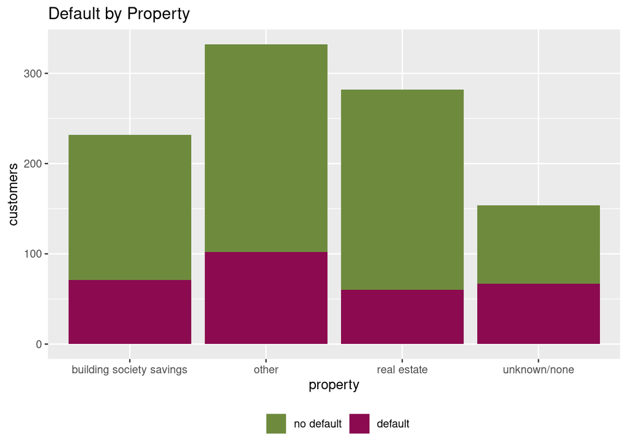

```r
plotbyProperty<-ggplot(credit,aes(property,fill=default))+geom_bar() +labs(x="property", y="customers")+ guides(fill=guide_legend(title=""))+  theme(legend.position = 'bottom')+ scale_fill_manual(values=c("darkolivegreen4","deeppink4"))+ggtitle("Default by Property")

plotbyProperty
```

```r
t_property <- prop.table(table(credit$property, credit$default), margin=1)

round(t_property, 2)
```

```
##
##                            no default default
##   building society savings       0.69    0.31
##   other                          0.69    0.31
##   real estate                    0.79    0.21
##   unknown/none                   0.56    0.44
```

```r
CramerV(t_property)
```

```
## [1] 0.170179
```

Pel que fa al tipus de propietat del client, el grup de propietaris immobiliaris mostren un percentatge baix d’impagaments, mentre que hi ha més impagaments quan els clients no són propietaris de cal tipus (o quan ens manca la informació). L’associació estadística torna a ser feble per a aquesta variable.

### Job:

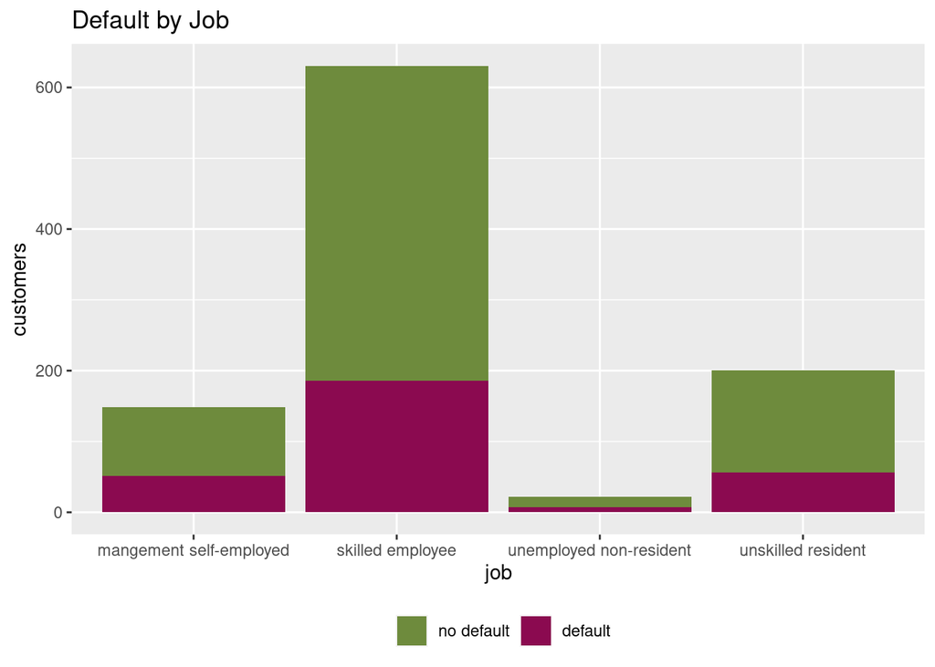

```r
plotbyJob<-ggplot(credit,aes(job,fill=default))+geom_bar() +labs(x="job", y="customers")+ guides(fill=guide_legend(title=""))+  theme(legend.position = 'bottom')+ scale_fill_manual(values=c("darkolivegreen4","deeppink4"))+ggtitle("Default by Job")

plotbyJob
```

```r
t_job <- prop.table(table(credit$job, credit$default), margin=1)

round(t_job, 2)
```

```
##
##                           no default default
##   mangement self-employed       0.66    0.34
##   skilled employee              0.70    0.30
##   unemployed non-resident       0.68    0.32
##   unskilled resident            0.72    0.28
```

```r
CramerV(t_job)
```

```
## [1] 0.05277215
```

Pel que fa a la variable d’estatut laboral, les diferències no són molt grans, però sembla que hi ha més impagaments en el grup d’autònoms. L’associació estadística és particularment feble en aquest cas.

## Primer arbre de decisió.

Seleccionem totes les variables categòriques del joc de dades (les que ja ho eren i les que hem discretitzat):

```r
credit_a <- credit[, c(1, 3, 4, 6, 7, 8, 9, 10, 11, 12, 14, 15, 16, 18, 19, 20, 21, 22, 23, 24, 17)]
```

No sembla que els registren estiguin ordenats, però per si de cas, randomitzem el joc de dades:

```r
set.seed(1)
credit_random <- credit_a[sample(nrow(credit_a)),]
```

Aïllem la variable classificadora (‘default’):

```r
set.seed(666)
y <- credit_random[,21]
X <- credit_random[,1:20]
```

Creem els grups d’entrenament i test:

```r
split_prop <- 3
indexes = sample(1:nrow(credit_a), size=floor(((split_prop-1)/split_prop)*nrow(credit_a)))
trainX<-X[indexes,]
trainy<-y[indexes]
testX<-X[-indexes,]
testy<-y[-indexes]
```

Comprovem que la creació dels grups resulta equilibrada:

```r
sum(summary(trainy))
```

```
## [1] 666
```

```r
sum(summary(trainX$telephone))
```

```
## [1] 666
```

```r
sum(summary(testy))
```

```
## [1] 334
```

```r
sum(summary(testX$checking_balance))
```

```
## [1] 334
```

Apliquem un primer model d’arbre de decisió, mostrant les regles:

```r
trainy = as.factor(trainy)
model <- C50::C5.0(trainX, trainy, rules=TRUE)
summary(model)
```

```
##
## Call:
## C5.0.default(x = trainX, y = trainy, rules = TRUE)
##
##
## C5.0 [Release 2.07 GPL Edition]      Wed May 18 14:15:18 2022
## -------------------------------
##
## Class specified by attribute `outcome'
##
## Read 666 cases (21 attributes) from undefined.data
##
## Rules:
##
## Rule 1: (56/2, lift 1.4)
##  credit_history = critical
##  installment_rate = 4
##  personal_status in {female, married male, single male}
##  other_installment_plan = none
##  amount_d = low
##  ->  class no default  [0.948]
##
## Rule 2: (10, lift 1.3)
##  checking_balance in {< 0 DM, 1 - 200 DM}
##  savings_balance = > 1000 DM
##  ->  class no default  [0.917]
##
## Rule 3: (286/34, lift 1.3)
##  checking_balance in {> 200 DM, unknown}
##  other_debtors = none
##  ->  class no default  [0.878]
##
## Rule 4: (20/2, lift 1.2)
##  checking_balance in {< 0 DM, 1 - 200 DM}
##  credit_history = repaid
##  other_debtors = guarantor
##  ->  class no default  [0.864]
##
## Rule 5: (120/16, lift 1.2)
##  amount_d in {low, medium}
```

[output cut: 54 more lines]

```
##   81.68% installment_rate
##   73.57% checking_balance
##   46.55% other_debtors
##   40.84% credit_duration_d
##   30.18% amount_d
##   24.92% savings_balance
##   12.01% credit_history
##    8.41% personal_status
##    8.41% other_installment_plan
##    1.80% telephone
##    1.80% foreign_worker
##    1.80% job
##
##
## Time: 0.0 secs
```

Tenim una gran quantitat de variables, i el resultat de l’arbre de decisió és complex, contenent fins a 10 regles. Si prenem com a exemple la regla #1, veiem que si el client té un historial de crèdit ‘crític’, un ‘installment rate’ amb valor 4, demana una quantitat de diners baixa en crèdit, no és un home divorciat i no té altres pagaments a terminis, podem assumir amb un nivell de confiança del 95% que el client no caurà en impagament. Aquesta regla ha inclòs 56 casos de la mostra amb les característiques esmentades, i en 2 d’aquests casos sí que hi ha impagament. El valor ‘lift’, que en el cas de la primera regla és de 1.4, resulta de dividir el nivell de precisió estimada de la regla per la freqüència relativa dels casos predits dintre de la mostra.

Una regla més senzilla de resumir seria la regla #9, que indica que si el client té menys de 200DM al compte d’estalvis i demana una quantitat alta de crèdit, podem esperar amb un 80% de confiança que realitzarà impagament. Val a dir però que aquesta regla només inclou 24 casos amb aquestes característiques, inclosos 4 casos que no van cometre impagament.

En general, l’estimació de l’error del model és d’un 20.1%, i a la llista al final del resum podem trobar les variables que s’han utilitzat en la creació del model, on hi destaquen amb majors percentatges les variables ‘installment rate’ i ‘ckeckings balance’

A continuació mostrem un gràfic amb l’arbre de decisió, tot i que la gran quantitat de variables i regles en fa difícil la interpretació:

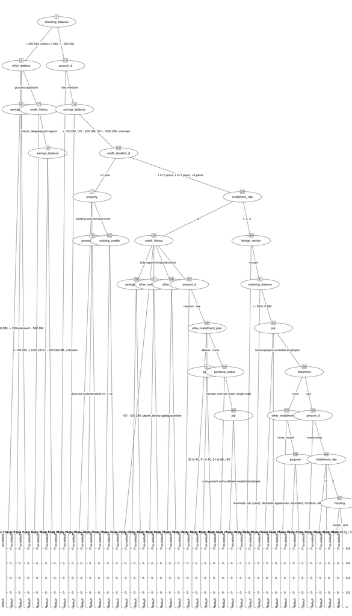

```r
model_plot <- C50::C5.0(trainX, trainy)
plot(model_plot)
```

## Anàlisi de la bondat d’ajust sobre el conjunt de test

Si utilitzem aquest primer model sobre les el conjunt test, obtenim una precisió d’un 72.16%:

```r
predicted_model <- predict( model, testX, type="class" )
print(sprintf("La precisió de l'arbre de decisió es: %.4f %%",100*sum(predicted_model == testy) / length(predicted_model)))
```

```
## [1] "La precisió de l'arbre de decisió es: 72.1557 %"
```

Mostrem la taula de confusió on es visualitzen veritables i falsos positius i negatius en la predicció generada pel model sobre el conjunt test:

```r
mat_conf<-table(testy,Predicted=predicted_model)
mat_conf
```

```
##             Predicted
## testy        no default default
##   no default        209      29
##   default            64      32
```

```r
if(!require(gmodels)){
    install.packages('gmodels', repos='http://cran.us.r-project.org')
    library(gmodels)
}
```

Mostrem la mateixa taula de confusió amb la suma dels totals. En aquesta matriu de confusió, el valor ‘29’, que és el nombre de falsos positius (nombre de clients que el model prediu que faran impagament que en realitat no en fan), representa l’error de Tipus I. El valor ‘64’ (falsos negatius: clients que el model prediu que no cauran en impagament però que sí que hi cauen) representa l’error de Tipus II.

```r
CrossTable(testy, predicted_model,prop.chisq  = FALSE, prop.c = FALSE, prop.r =FALSE,dnn = c('Reality', 'Prediction'))
```

```
##
##
##    Cell Contents
## |-------------------------|
## |                       N |
## |         N / Table Total |
## |-------------------------|
##
##
## Total Observations in Table:  334
##
##
##              | Prediction
##      Reality | no default |    default |  Row Total |
## -------------|------------|------------|------------|
##   no default |        209 |         29 |        238 |
##              |      0.626 |      0.087 |            |
## -------------|------------|------------|------------|
##      default |         64 |         32 |         96 |
##              |      0.192 |      0.096 |            |
## -------------|------------|------------|------------|
## Column Total |        273 |         61 |        334 |
## -------------|------------|------------|------------|
##
##
```

Més avall, quan comparem aquest model amb els següents models que generarem, especificarem la comparativa entre les diverses mètriques de validesa que podem extreure de les matrius de confusió de cada model.

Un cop analitzat aquest model, podem afirmar que té una capacitat de predicció notable sobre el conjunt test, però ens sembla que pot ser millorable.

## Ajust de models complementaris.

Crearem un segon model incorporant l’opció ‘adaptative boosting’:

```r
model_02 <- C50::C5.0(trainX, trainy, trials = 10)
```

Veiem directament que amb aquest segon model, augmentem des d’una precisió del 72.16% fins a un 76.9%. La millora doncs és considerable:

```r
predicted_model2 <- predict( model_02, testX, type="class" )
print(sprintf("La precisió del segon arbre: %.4f %%",100*sum(predicted_model2 == testy) / length(predicted_model2)))
```

```
## [1] "La precisió del segon arbre: 76.9461 %"
```

Mostrem la taula de confusió d’aquest segon model:

```r
mat_conf<-table(testy,Predicted=predicted_model2)
mat_conf
```

```
##             Predicted
## testy        no default default
##   no default        211      27
##   default            50      46
```

### Random Forest

Tot seguit, generem un model amb l’algorisme RandomForest. En aquest cas, no separem la variable classificadora (aquesta s’especifica en els paràmetres de la funció que executa el model). Generem grups d’entrenament i test que quantitats idèntiques als models anteriors, i això ens permetrà més endavant comparar les matrius de confusió de cada model:

```r
set.seed(123)

samp <- sample(nrow(credit_a), 0.666 * nrow(credit_a))

train <- credit_a[samp, ]

test <- credit_a[-samp, ]
```

```r
library(randomForest)
model_rf <- randomForest(default~., data = train)
model_rf
```

```
##
## Call:
##  randomForest(formula = default ~ ., data = train)
##                Type of random forest: classification
##                      Number of trees: 500
## No. of variables tried at each split: 4
##
##         OOB estimate of  error rate: 24.62%
## Confusion matrix:
##            no default default class.error
## no default        428      41  0.08742004
## default           123      74  0.62436548
```

Per a aquest model, obtenim una estimació d’error d’un 24.6%, havent utilitzat 4 variables a cada bifurcació del model. Amb aquest model obtenim una precisió del 76.9%, idèntica a la que obteníem amb el segon model (C5.0 amb adaptative boosting):

```r
prediction_rf <- predict(model_rf, newdata = test)

table(prediction_rf, test$default)
```

```
##
## prediction_rf no default default
##    no default        210      56
##    default            21      47
```

```r
sum(prediction_rf==test$default) / nrow(test)
```

```
## [1] 0.7694611
```

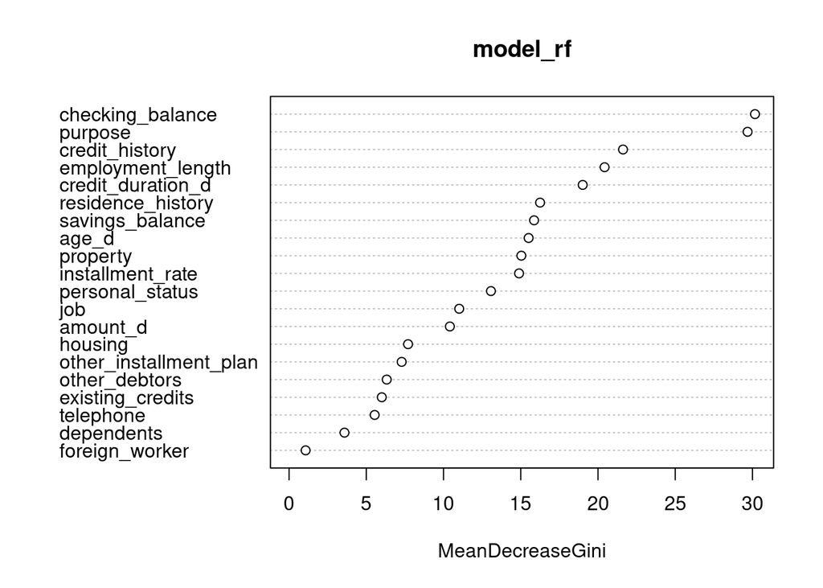

```r
varImpPlot(model_rf)
```

A continuació mostrem la comparativa de les matrius de confusió de cadascun dels models, incloent-hi les mètriques de sensitivitat i especificitat. En podem concloure que el segon i el tercer model milloren la precisió respecte al primer model, amb la particularitat que el segon model mostra una millor sensitivitat (veritables positius correctament identificats), mentre que el model generat amb RandomForest mostra una especificitat lleugerament més alta (veritables negatius correctament identificats).

```r
library(caret)
confusionMatrix(data=testy, reference = predicted_model)
```

```
## Confusion Matrix and Statistics
##
##             Reference
## Prediction   no default default
##   no default        209      29
##   default            64      32
##
##                Accuracy : 0.7216
##                  95% CI : (0.6702, 0.769)
##     No Information Rate : 0.8174
##     P-Value [Acc > NIR] : 0.9999935
##
##                   Kappa : 0.2373
##
##  Mcnemar's Test P-Value : 0.0004225
##
##             Sensitivity : 0.7656
##             Specificity : 0.5246
##          Pos Pred Value : 0.8782
##          Neg Pred Value : 0.3333
##              Prevalence : 0.8174
##          Detection Rate : 0.6257
##    Detection Prevalence : 0.7126
##       Balanced Accuracy : 0.6451
##
##        'Positive' Class : no default
##
```

```r
confusionMatrix(data=testy, reference = predicted_model2)
```

```
## Confusion Matrix and Statistics
##
##             Reference
## Prediction   no default default
##   no default        211      27
##   default            50      46
##
##                Accuracy : 0.7695
##                  95% CI : (0.7205, 0.8136)
##     No Information Rate : 0.7814
##     P-Value [Acc > NIR] : 0.72699
##
##                   Kappa : 0.3939
##
##  Mcnemar's Test P-Value : 0.01217
##
##             Sensitivity : 0.8084
##             Specificity : 0.6301
##          Pos Pred Value : 0.8866
##          Neg Pred Value : 0.4792
##              Prevalence : 0.7814
##          Detection Rate : 0.6317
##    Detection Prevalence : 0.7126
##       Balanced Accuracy : 0.7193
##
##        'Positive' Class : no default
##
```

```r
confusionMatrix(data=test$default, reference = prediction_rf)
```

```
## Confusion Matrix and Statistics
##
##             Reference
## Prediction   no default default
##   no default        210      21
##   default            56      47
##
##                Accuracy : 0.7695
##                  95% CI : (0.7205, 0.8136)
##     No Information Rate : 0.7964
##     P-Value [Acc > NIR] : 0.9002321
##
##                   Kappa : 0.4034
##
##  Mcnemar's Test P-Value : 0.0001068
##
##             Sensitivity : 0.7895
##             Specificity : 0.6912
##          Pos Pred Value : 0.9091
##          Neg Pred Value : 0.4563
##              Prevalence : 0.7964
##          Detection Rate : 0.6287
##    Detection Prevalence : 0.6916
##       Balanced Accuracy : 0.7403
##
##        'Positive' Class : no default
##
```

## Resum de les principals conclusions

Hem implementat tres models de predicció supervisada sobre un joc de dades referent a les diverses característiques de demandants de crèdits a Alemanya. Es tracta d’un joc de dades amb 1000 registres i 21 variables. Una gran part de les variables són categòriques, incloent-hi descripcions categoritzades de variables d’origen numèric, com per exemple la quantitat d’estalvis o els anys de contracte laboral. Hem discretitzat les variables contínues per tal d’implementar els nostres models d’arbres de decisió sobre variables categòriques en la seva totalitat.

En l’estudi descriptiu de les variables no hem descobert valors nuls o erronis, però ens ha sobtat la forma en que estaven construïdes algunes de les variables. Hem trobat atípic el fet que més del 95% dels registres provenien de treballadors estrangers, que es barregin en una sola variable el sexe i l’estat civil de forma que només s’obté informació de l’estat civil dels homes, i que algunes variables com el nombre de persones independents o el nombre d’anys de residència tinguin valors molt limitats.